# Investigate a Dateset Project

Egypt, Cairo

By Sherif Ahmed Abdelmagid Sakr

The FBI Gun Data Analysis Project as a part of Udacity Advanced Data Analyst Nanodegree Program is focus on analyze a dataset, use the Python libraries such as NumPy, pandas, Matplotlib, etc., and then communicate the findings about it, I apply the data analysis process which consists of asking questions, wrangling data (data gathering, data assessing, and data cleaning), exploring data analysis, draw conclusions, and communicate the findings.

The Federal Bureau of Investigation (FBI) is the domestic intelligence and security service of the United States of America, and its principal federal law enforcement agency. Operating under the jurisdiction of United States Department of Justice, the FBI is also a member of the U.S. Intelligence Community and reports to both the Attorney General and the Director of the National Intelligence.

Furthermore, FBI, the National Instant Criminal Backgroud Check System (NICS) is a background check system in the U.S. created by the Brady Handgun Violence Prevention Act, it short for Brady Act of 1993 to prevent firearm sales to people prohibited under the Act. The system was launched by the FBI in 1998.

Under the system, firearm dealers, gun shop owners, pawn shop dealer, retailer, manufactures, or importers who hold a Federal Firearms License (FFL) are required to undertakers a NICS background check on prospective buyers before transferring a firearm. However, NICS determine whether a person can legally buy or own a firearm. Operated by the FBI, NICS was developed with the Bureau of Alcohol, Tabacco, Firearms, and Explosives (ATF), and state, and law enforement agencies.

More details at:"https://www.fbi.gov/services/cjis/nics"

What will I learn? After completing the project, you will:

- Know all the steps involved in a typical data analysis process
- Be comfortable posing questions that can be answered with a given dataset and then answering those questions
- Know how to investigate problems in a dataset and wrangle the data into a format you can use
- Have practice communicating the results of your analysis
- Be able to use vectorized operations in NumPy and Pandas to speed up your data analysis code
- Be familiar with pandas' Series and DataFrame objects, which let you access your data more conveniently
- Know how to use Matplotlib to produce plots showing your findings

```python
print('-'*120)
```

### Fist Step: Asking Question

Research Questions:

- What is the total firearms registration in each U.S. States during the period from 1 November 1998 untill 1 September 2017?
- What are the U.S. States with the highest number of the total firearms registration during the period from 1 November 1998 untill 1 September 2017?
- What are the top ten U.S. States with the highest number of the total firearms registration during the period from 1 November 1998untill 1 September 2017?
- What is the arithmetic mean (average) of the total firearms registration of each U.S. States during the period from 1 November 1998untill 1 September 2017?
- Which U.S. States have the highest population in the 2016 census?
- Which U.S. States have the highest population in the 2010 census?
- What are the total payroll in each U.S. States over the 2015 year?
- What are the total revenues of all firms in each of the U.S. States over the 2012 year?
- What is the total firearms registration in each U.S. States over the 2017 year?
- What is the highest number of total firearms registration over the U.S. States and over the 2017 year?
- What is the lowest number of total firearms registration over the U.S. States and over the 2017 year?
- What census data is most associated with the highest firearms registration per capita over the 2016 year?
- Which U.S. States has the highest growth number of firearms registeration during the period from 1 November 1998 untill 1 September 2017?
- What is the overall trend of firearms purchases?

Independent and Dependent Variables

- In research, variables are any characteristics that can take on different values, such as height, temperature, age, species, or exam score. The variable in a study of a cause-and-effect relationship are called the independent and dependent variables.
- The independent variable is the cause, its value is independent of other variables in the study. However, the dependent variable is the effect, its value depends on changes in the independent variable.
- In other words, the independent variable is the variable the experimenter changes or controls and is assumed to have a direct effect on the dependent variable.
- The research questions promote looking at relationships between multiple variables, and I aim to analyze at least one dependent variable and three independent variables in my investigation.
- The dependent variable is the 'totals' column in the gun_data dataset representing the sum of all numerical columns of background checks data for each U.S. States.
- The independent variables are all numerical variables in the U.S. census dataset.
- Quantitative variables are any variables where the data represent amounts, and are numeric values that allows mathematical operations like most of the variables in this project (e.g. permits, totals 2010_population, and 2016_populations).
- However, the categorical variables are any variables where the data represent groups. This includes rankings (e.g. finishing places in a race), classifications (e.g. brands of cereal), and binary outcomes (e.g. coin flips).

### Second Step: Wrangling Data

```python
# Import Python Libraries
import pandas as pd
import numpy as np
import matplotlib.pyplot as plt
import seaborn as sns
%matplotlib inline
from scipy.stats import pearsonr
import datetime
```

```python
# Gathering Data
```

Load datasets to pandas Dataframe:

- A U.S. Census Data CSV file. It contains several variables at the state level. Most variables just have one data point per state.

- A NCIS Gun Data MS Excel file.It contains the number of firearm checks by month, state, and type.

- The datasets cover the period from November 1, 1998 untill September 1, 2017.

Note that, a comma-separate values (CSV) file is a delimited text file that use a comma to separate values.

```python
# Reading CSV file dataset
df_census = pd.read_csv('US_Census_Data.csv')
# Reading Excel file dataset
df_gun = pd.read_excel('Gun_Data.xlsx')
```

```python
# Assessing Data
```

There are two types of Data Assessment:

- Visual assessment: the two datasets is displayed in the Jupyter Notebook for visual assessment purposes, once displayed, data can additionally be assessed in an extra applications such as Microsoft Excel, Google Sheets, and Text editor.
- Programmatic assessment: using codes, such as Pandas' functions and methods.

```python
# Use pandas.DataFrame.info() to Print a concise summary of a DataFrame, including the index dtype and columns,
# non-null values, and memory usage.
df_census.info()
```

```
<class 'pandas.core.frame.DataFrame'>
RangeIndex: 85 entries, 0 to 84
Data columns (total 52 columns):
 #   Column          Non-Null Count  Dtype
---  ------          --------------  -----
 0   Fact            80 non-null     object
 1   Fact Note       28 non-null     object
 2   Alabama         65 non-null     object
 3   Alaska          65 non-null     object
 4   Arizona         65 non-null     object
 5   Arkansas        65 non-null     object
 6   California      65 non-null     object
 7   Colorado        65 non-null     object
 8   Connecticut     65 non-null     object
 9   Delaware        65 non-null     object
```

[output cut: 44 more lines]

```python
# Use pandas.DataFrame.info() to Print a concise summary of a DataFrame, including the index dtype and columns,
# non-null values, and memory usage.
df_gun.info()
```

```
<class 'pandas.core.frame.DataFrame'>
RangeIndex: 12485 entries, 0 to 12484
Data columns (total 27 columns):
 #   Column                     Non-Null Count  Dtype
---  ------                     --------------  -----
 0   month                      12485 non-null  object
 1   state                      12485 non-null  object
 2   permit                     12461 non-null  float64
 3   permit_recheck             1100 non-null   float64
 4   handgun                    12465 non-null  float64
 5   long_gun                   12466 non-null  float64
 6   other                      5500 non-null   float64
 7   multiple                   12485 non-null  int64
 8   admin                      12462 non-null  float64
 9   prepawn_handgun            10542 non-null  float64
```

[output cut: 19 more lines]

```python
# Use a pandas.DataFrame.head(n=5) function to return the first numbers of rows for the object based on position.
df_census.head()
```

|  | Fact | Fact Note | Alabama | Alaska | Arizona | Arkansas | California | Colorado | Connecticut | Delaware | ... | South Dakota | Tennessee | Texas | Utah | Vermont | Virginia | Washington | West Virginia | Wisconsin | Wyoming |
| --- | --- | --- | --- | --- | --- | --- | --- | --- | --- | --- | --- | --- | --- | --- | --- | --- | --- | --- | --- | --- | --- |
| 0 | Population estimates, July 1, 2016, (V2016) | NaN | 4,863,300 | 741,894 | 6,931,071 | 2,988,248 | 39,250,017 | 5,540,545 | 3,576,452 | 952,065 | ... | 865454 | 6651194 | 27,862,596 | 3,051,217 | 624,594 | 8,411,808 | 7,288,000 | 1,831,102 | 5,778,708 | 585,501 |
| 1 | Population estimates base, April 1, 2010, (V2... | NaN | 4,780,131 | 710,249 | 6,392,301 | 2,916,025 | 37,254,522 | 5,029,324 | 3,574,114 | 897,936 | ... | 814195 | 6346298 | 25,146,100 | 2,763,888 | 625,741 | 8,001,041 | 6,724,545 | 1,853,011 | 5,687,289 | 563,767 |
| 2 | Population, percent change - April 1, 2010 (es... | NaN | 1.70% | 4.50% | 8.40% | 2.50% | 5.40% | 10.20% | 0.10% | 6.00% | ... | 0.063 | 0.048 | 10.80% | 10.40% | -0.20% | 5.10% | 8.40% | -1.20% | 1.60% | 3.90% |
| 3 | Population, Census, April 1, 2010 | NaN | 4,779,736 | 710,231 | 6,392,017 | 2,915,918 | 37,253,956 | 5,029,196 | 3,574,097 | 897,934 | ... | 814180 | 6346105 | 25,145,561 | 2,763,885 | 625,741 | 8,001,024 | 6,724,540 | 1,852,994 | 5,686,986 | 563,626 |
| 4 | Persons under 5 years, percent, July 1, 2016, ... | NaN | 6.00% | 7.30% | 6.30% | 6.40% | 6.30% | 6.10% | 5.20% | 5.80% | ... | 0.071 | 0.061 | 7.20% | 8.30% | 4.90% | 6.10% | 6.20% | 5.50% | 5.80% | 6.50% |

5 rows × 52 columns

```python
# Use a pandas.DataFrame.head(n=5) function to return the first numbers of rows for the object based on position.
df_gun.head()
```

|  | month | state | permit | permit_recheck | handgun | long_gun | other | multiple | admin | prepawn_handgun | ... | returned_other | rentals_handgun | rentals_long_gun | private_sale_handgun | private_sale_long_gun | private_sale_other | return_to_seller_handgun | return_to_seller_long_gun | return_to_seller_other | totals |
| --- | --- | --- | --- | --- | --- | --- | --- | --- | --- | --- | --- | --- | --- | --- | --- | --- | --- | --- | --- | --- | --- |
| 0 | 2017-09 | Alabama | 16717.0 | 0.0 | 5734.0 | 6320.0 | 221.0 | 317 | 0.0 | 15.0 | ... | 0.0 | 0.0 | 0.0 | 9.0 | 16.0 | 3.0 | 0.0 | 0.0 | 3.0 | 32019 |
| 1 | 2017-09 | Alaska | 209.0 | 2.0 | 2320.0 | 2930.0 | 219.0 | 160 | 0.0 | 5.0 | ... | 0.0 | 0.0 | 0.0 | 17.0 | 24.0 | 1.0 | 0.0 | 0.0 | 0.0 | 6303 |
| 2 | 2017-09 | Arizona | 5069.0 | 382.0 | 11063.0 | 7946.0 | 920.0 | 631 | 0.0 | 13.0 | ... | 0.0 | 0.0 | 0.0 | 38.0 | 12.0 | 2.0 | 0.0 | 0.0 | 0.0 | 28394 |
| 3 | 2017-09 | Arkansas | 2935.0 | 632.0 | 4347.0 | 6063.0 | 165.0 | 366 | 51.0 | 12.0 | ... | 0.0 | 0.0 | 0.0 | 13.0 | 23.0 | 0.0 | 0.0 | 2.0 | 1.0 | 17747 |
| 4 | 2017-09 | California | 57839.0 | 0.0 | 37165.0 | 24581.0 | 2984.0 | 0 | 0.0 | 0.0 | ... | 0.0 | 0.0 | 0.0 | 0.0 | 0.0 | 0.0 | 0.0 | 0.0 | 0.0 | 123506 |

5 rows × 27 columns

```python
# Use a pandas.DataFrame.tail(n=5) function to return the last numbers of rows from the object based on position.
df_census.head()
```

|  | Fact | Fact Note | Alabama | Alaska | Arizona | Arkansas | California | Colorado | Connecticut | Delaware | ... | South Dakota | Tennessee | Texas | Utah | Vermont | Virginia | Washington | West Virginia | Wisconsin | Wyoming |
| --- | --- | --- | --- | --- | --- | --- | --- | --- | --- | --- | --- | --- | --- | --- | --- | --- | --- | --- | --- | --- | --- |
| 0 | Population estimates, July 1, 2016, (V2016) | NaN | 4,863,300 | 741,894 | 6,931,071 | 2,988,248 | 39,250,017 | 5,540,545 | 3,576,452 | 952,065 | ... | 865454 | 6651194 | 27,862,596 | 3,051,217 | 624,594 | 8,411,808 | 7,288,000 | 1,831,102 | 5,778,708 | 585,501 |
| 1 | Population estimates base, April 1, 2010, (V2... | NaN | 4,780,131 | 710,249 | 6,392,301 | 2,916,025 | 37,254,522 | 5,029,324 | 3,574,114 | 897,936 | ... | 814195 | 6346298 | 25,146,100 | 2,763,888 | 625,741 | 8,001,041 | 6,724,545 | 1,853,011 | 5,687,289 | 563,767 |
| 2 | Population, percent change - April 1, 2010 (es... | NaN | 1.70% | 4.50% | 8.40% | 2.50% | 5.40% | 10.20% | 0.10% | 6.00% | ... | 0.063 | 0.048 | 10.80% | 10.40% | -0.20% | 5.10% | 8.40% | -1.20% | 1.60% | 3.90% |
| 3 | Population, Census, April 1, 2010 | NaN | 4,779,736 | 710,231 | 6,392,017 | 2,915,918 | 37,253,956 | 5,029,196 | 3,574,097 | 897,934 | ... | 814180 | 6346105 | 25,145,561 | 2,763,885 | 625,741 | 8,001,024 | 6,724,540 | 1,852,994 | 5,686,986 | 563,626 |
| 4 | Persons under 5 years, percent, July 1, 2016, ... | NaN | 6.00% | 7.30% | 6.30% | 6.40% | 6.30% | 6.10% | 5.20% | 5.80% | ... | 0.071 | 0.061 | 7.20% | 8.30% | 4.90% | 6.10% | 6.20% | 5.50% | 5.80% | 6.50% |

5 rows × 52 columns

```python
# Use a pandas.DataFrame.tail(n=5) function to return the last numbers of rows from the object based on position.
df_gun.head()
```

|  | month | state | permit | permit_recheck | handgun | long_gun | other | multiple | admin | prepawn_handgun | ... | returned_other | rentals_handgun | rentals_long_gun | private_sale_handgun | private_sale_long_gun | private_sale_other | return_to_seller_handgun | return_to_seller_long_gun | return_to_seller_other | totals |
| --- | --- | --- | --- | --- | --- | --- | --- | --- | --- | --- | --- | --- | --- | --- | --- | --- | --- | --- | --- | --- | --- |
| 0 | 2017-09 | Alabama | 16717.0 | 0.0 | 5734.0 | 6320.0 | 221.0 | 317 | 0.0 | 15.0 | ... | 0.0 | 0.0 | 0.0 | 9.0 | 16.0 | 3.0 | 0.0 | 0.0 | 3.0 | 32019 |
| 1 | 2017-09 | Alaska | 209.0 | 2.0 | 2320.0 | 2930.0 | 219.0 | 160 | 0.0 | 5.0 | ... | 0.0 | 0.0 | 0.0 | 17.0 | 24.0 | 1.0 | 0.0 | 0.0 | 0.0 | 6303 |
| 2 | 2017-09 | Arizona | 5069.0 | 382.0 | 11063.0 | 7946.0 | 920.0 | 631 | 0.0 | 13.0 | ... | 0.0 | 0.0 | 0.0 | 38.0 | 12.0 | 2.0 | 0.0 | 0.0 | 0.0 | 28394 |
| 3 | 2017-09 | Arkansas | 2935.0 | 632.0 | 4347.0 | 6063.0 | 165.0 | 366 | 51.0 | 12.0 | ... | 0.0 | 0.0 | 0.0 | 13.0 | 23.0 | 0.0 | 0.0 | 2.0 | 1.0 | 17747 |
| 4 | 2017-09 | California | 57839.0 | 0.0 | 37165.0 | 24581.0 | 2984.0 | 0 | 0.0 | 0.0 | ... | 0.0 | 0.0 | 0.0 | 0.0 | 0.0 | 0.0 | 0.0 | 0.0 | 0.0 | 123506 |

5 rows × 27 columns

```python
# Use pandas DataFrame.iloc[] for integer-location based indexing for selection by position
df_census.iloc[0]
```

```
Fact              Population estimates, July 1, 2016,  (V2016)
Fact Note                                                  NaN
Alabama                                              4,863,300
Alaska                                                 741,894
Arizona                                              6,931,071
Arkansas                                             2,988,248
California                                          39,250,017
Colorado                                             5,540,545
Connecticut                                          3,576,452
Delaware                                               952,065
Florida                                             20,612,439
Georgia                                             10,310,371
Hawaii                                               1,428,557
Idaho                                                1,683,140
Illinois                                            12,801,539
Indiana                                              6,633,053
Iowa                                                 3,134,693
Kansas                                               2,907,289
Kentucky                                             4,436,974
Louisiana                                            4,681,666
Maine                                                1,331,479
Maryland                                             6,016,447
Massachusetts                                        6,811,779
Michigan                                             9,928,300
Minnesota                                            5,519,952
Mississippi                                          2,988,726
Missouri                                             6,093,000
Montana                                              1,042,520
Nebraska                                             1,907,116
Nevada                                               2,940,058
New Hampshire                                        1,334,795
New Jersey                                           8,944,469
New Mexico                                             2081015
New York                                              19745289
North Carolina                                        10146788
North Dakota                                            757952
Ohio                                                  11614373
Oklahoma                                               3923561
Oregon                                                 4093465
Pennsylvania                                          12784227
Rhode Island                                           1056426
South Carolina                                         4961119
South Dakota                                            865454
Tennessee                                              6651194
Texas                                               27,862,596
Utah                                                 3,051,217
Vermont                                                624,594
Virginia                                             8,411,808
Washington                                           7,288,000
West Virginia                                        1,831,102
Wisconsin                                            5,778,708
Wyoming                                                585,501
Name: 0, dtype: object
```

```python
# Show the population estimates in April 1, 2010 and in July 1, 2016, in the first two rows in U.S. Census dataframe.
df_census.iloc[:2]
```

|  | Fact | Fact Note | Alabama | Alaska | Arizona | Arkansas | California | Colorado | Connecticut | Delaware | ... | South Dakota | Tennessee | Texas | Utah | Vermont | Virginia | Washington | West Virginia | Wisconsin | Wyoming |
| --- | --- | --- | --- | --- | --- | --- | --- | --- | --- | --- | --- | --- | --- | --- | --- | --- | --- | --- | --- | --- | --- |
| 0 | Population estimates, July 1, 2016, (V2016) | NaN | 4,863,300 | 741,894 | 6,931,071 | 2,988,248 | 39,250,017 | 5,540,545 | 3,576,452 | 952,065 | ... | 865454 | 6651194 | 27,862,596 | 3,051,217 | 624,594 | 8,411,808 | 7,288,000 | 1,831,102 | 5,778,708 | 585,501 |
| 1 | Population estimates base, April 1, 2010, (V2... | NaN | 4,780,131 | 710,249 | 6,392,301 | 2,916,025 | 37,254,522 | 5,029,324 | 3,574,114 | 897,936 | ... | 814195 | 6346298 | 25,146,100 | 2,763,888 | 625,741 | 8,001,041 | 6,724,545 | 1,853,011 | 5,687,289 | 563,767 |

2 rows × 52 columns

```python
# Show the useless data in rows in the U.S. Census DataFrame
df_census.iloc[64:]
```

|  | Fact | Fact Note | Alabama | Alaska | Arizona | Arkansas | California | Colorado | Connecticut | Delaware | ... | South Dakota | Tennessee | Texas | Utah | Vermont | Virginia | Washington | West Virginia | Wisconsin | Wyoming |
| --- | --- | --- | --- | --- | --- | --- | --- | --- | --- | --- | --- | --- | --- | --- | --- | --- | --- | --- | --- | --- | --- |
| 64 | FIPS Code | NaN | "01" | "02" | "04" | "05" | "06" | "08" | "09" | "10" | ... | "46" | "47" | "48" | "49" | "50" | "51" | "53" | "54" | "55" | "56" |
| 65 | NaN | NaN | NaN | NaN | NaN | NaN | NaN | NaN | NaN | NaN | ... | NaN | NaN | NaN | NaN | NaN | NaN | NaN | NaN | NaN | NaN |
| 66 | NOTE: FIPS Code values are enclosed in quotes ... | NaN | NaN | NaN | NaN | NaN | NaN | NaN | NaN | NaN | ... | NaN | NaN | NaN | NaN | NaN | NaN | NaN | NaN | NaN | NaN |
| 67 | NaN | NaN | NaN | NaN | NaN | NaN | NaN | NaN | NaN | NaN | ... | NaN | NaN | NaN | NaN | NaN | NaN | NaN | NaN | NaN | NaN |
| 68 | Value Notes | NaN | NaN | NaN | NaN | NaN | NaN | NaN | NaN | NaN | ... | NaN | NaN | NaN | NaN | NaN | NaN | NaN | NaN | NaN | NaN |
| 69 | 1 | Includes data not distributed by county. | NaN | NaN | NaN | NaN | NaN | NaN | NaN | NaN | ... | NaN | NaN | NaN | NaN | NaN | NaN | NaN | NaN | NaN | NaN |
| 70 | NaN | NaN | NaN | NaN | NaN | NaN | NaN | NaN | NaN | NaN | ... | NaN | NaN | NaN | NaN | NaN | NaN | NaN | NaN | NaN | NaN |
| 71 | Fact Notes | NaN | NaN | NaN | NaN | NaN | NaN | NaN | NaN | NaN | ... | NaN | NaN | NaN | NaN | NaN | NaN | NaN | NaN | NaN | NaN |
| 72 | (a) | Includes persons reporting only one race | NaN | NaN | NaN | NaN | NaN | NaN | NaN | NaN | ... | NaN | NaN | NaN | NaN | NaN | NaN | NaN | NaN | NaN | NaN |
| 73 | (b) | Hispanics may be of any race, so also are incl... | NaN | NaN | NaN | NaN | NaN | NaN | NaN | NaN | ... | NaN | NaN | NaN | NaN | NaN | NaN | NaN | NaN | NaN | NaN |
| 74 | (c) | Economic Census - Puerto Rico data are not com... | NaN | NaN | NaN | NaN | NaN | NaN | NaN | NaN | ... | NaN | NaN | NaN | NaN | NaN | NaN | NaN | NaN | NaN | NaN |
| 75 | NaN | NaN | NaN | NaN | NaN | NaN | NaN | NaN | NaN | NaN | ... | NaN | NaN | NaN | NaN | NaN | NaN | NaN | NaN | NaN | NaN |
| 76 | Value Flags | NaN | NaN | NaN | NaN | NaN | NaN | NaN | NaN | NaN | ... | NaN | NaN | NaN | NaN | NaN | NaN | NaN | NaN | NaN | NaN |
| 77 | - | Either no or too few sample observations were ... | NaN | NaN | NaN | NaN | NaN | NaN | NaN | NaN | ... | NaN | NaN | NaN | NaN | NaN | NaN | NaN | NaN | NaN | NaN |
| 78 | D | Suppressed to avoid disclosure of confidential... | NaN | NaN | NaN | NaN | NaN | NaN | NaN | NaN | ... | NaN | NaN | NaN | NaN | NaN | NaN | NaN | NaN | NaN | NaN |
| 79 | F | Fewer than 25 firms | NaN | NaN | NaN | NaN | NaN | NaN | NaN | NaN | ... | NaN | NaN | NaN | NaN | NaN | NaN | NaN | NaN | NaN | NaN |
| 80 | FN | Footnote on this item in place of data | NaN | NaN | NaN | NaN | NaN | NaN | NaN | NaN | ... | NaN | NaN | NaN | NaN | NaN | NaN | NaN | NaN | NaN | NaN |
| 81 | NaN | Not available | NaN | NaN | NaN | NaN | NaN | NaN | NaN | NaN | ... | NaN | NaN | NaN | NaN | NaN | NaN | NaN | NaN | NaN | NaN |
| 82 | S | Suppressed; does not meet publication standards | NaN | NaN | NaN | NaN | NaN | NaN | NaN | NaN | ... | NaN | NaN | NaN | NaN | NaN | NaN | NaN | NaN | NaN | NaN |
| 83 | X | Not applicable | NaN | NaN | NaN | NaN | NaN | NaN | NaN | NaN | ... | NaN | NaN | NaN | NaN | NaN | NaN | NaN | NaN | NaN | NaN |
| 84 | Z | Value greater than zero but less than half uni... | NaN | NaN | NaN | NaN | NaN | NaN | NaN | NaN | ... | NaN | NaN | NaN | NaN | NaN | NaN | NaN | NaN | NaN | NaN |

21 rows × 52 columns

```python
# Use pandas DataFrame.iloc[] for integer-location based indexing for selection by position
df_gun.iloc[0]
```

```
month                        2017-09
state                        Alabama
permit                         16717
permit_recheck                     0
handgun                         5734
long_gun                        6320
other                            221
multiple                         317
admin                              0
prepawn_handgun                   15
prepawn_long_gun                  21
prepawn_other                      2
redemption_handgun              1378
redemption_long_gun             1262
redemption_other                   1
returned_handgun                   0
returned_long_gun                  0
returned_other                     0
rentals_handgun                    0
rentals_long_gun                   0
private_sale_handgun               9
private_sale_long_gun             16
private_sale_other                 3
return_to_seller_handgun           0
return_to_seller_long_gun          0
return_to_seller_other             3
totals                         32019
Name: 0, dtype: object
```

```python
# Use pandas.DataFrame.shape to return a tuple representing the dimensionality of the DataFrame
df_census.shape, df_gun.shape
```

```
((85, 52), (12485, 27))
```

```python
# Use pandas.DataFrame.ndim to return an integer representing the number of axes/ array dimensions.
df_census.ndim, df_gun.ndim
```

```
(2, 2)
```

```python
# viewing the type of the dataset
type(df_census), type(df_gun)
```

```
(pandas.core.frame.DataFrame, pandas.core.frame.DataFrame)
```

```python
# Use pandas.DataFrame.size to return an integer representing the number of elements in the object.
# It returns the number of rows if Series. Otherwise, it returns the number of rows times number of columns if DataFrame.
df_census.size, df_gun.size
```

```
(4420, 337095)
```

```python
# Use pandas.DataFrame.index to view the index (row labels) of the DataFrame.
df_census.index, df_gun.index
```

```
(RangeIndex(start=0, stop=85, step=1), RangeIndex(start=0, stop=12485, step=1))
```

```python
# Use pandas.DataFrame.columns to view the column labels of the Dataframe.
df_census.columns
```

```
Index(['Fact', 'Fact Note', 'Alabama', 'Alaska', 'Arizona', 'Arkansas',
       'California', 'Colorado', 'Connecticut', 'Delaware', 'Florida',
       'Georgia', 'Hawaii', 'Idaho', 'Illinois', 'Indiana', 'Iowa', 'Kansas',
       'Kentucky', 'Louisiana', 'Maine', 'Maryland', 'Massachusetts',
       'Michigan', 'Minnesota', 'Mississippi', 'Missouri', 'Montana',
       'Nebraska', 'Nevada', 'New Hampshire', 'New Jersey', 'New Mexico',
       'New York', 'North Carolina', 'North Dakota', 'Ohio', 'Oklahoma',
       'Oregon', 'Pennsylvania', 'Rhode Island', 'South Carolina',
       'South Dakota', 'Tennessee', 'Texas', 'Utah', 'Vermont', 'Virginia',
       'Washington', 'West Virginia', 'Wisconsin', 'Wyoming'],
      dtype='object')
```

```python
# Use pandas.DataFrame.columns to view the column labels of the Dataframe.
df_gun.columns
```

```
Index(['month', 'state', 'permit', 'permit_recheck', 'handgun', 'long_gun',
       'other', 'multiple', 'admin', 'prepawn_handgun', 'prepawn_long_gun',
       'prepawn_other', 'redemption_handgun', 'redemption_long_gun',
       'redemption_other', 'returned_handgun', 'returned_long_gun',
       'returned_other', 'rentals_handgun', 'rentals_long_gun',
       'private_sale_handgun', 'private_sale_long_gun', 'private_sale_other',
       'return_to_seller_handgun', 'return_to_seller_long_gun',
       'return_to_seller_other', 'totals'],
      dtype='object')
```

```python
# Use a Python built-in function list() to return a list in Python (the column names in pandas.DataFrame)
list(df_census)
```

```
['Fact',
 'Fact Note',
 'Alabama',
 'Alaska',
 'Arizona',
 'Arkansas',
 'California',
 'Colorado',
 'Connecticut',
 'Delaware',
 'Florida',
 'Georgia',
 'Hawaii',
 'Idaho',
 'Illinois',
 'Indiana',
 'Iowa',
 'Kansas',
 'Kentucky',
 'Louisiana',
 'Maine',
 'Maryland',
 'Massachusetts',
 'Michigan',
 'Minnesota',
 'Mississippi',
 'Missouri',
 'Montana',
 'Nebraska',
 'Nevada',
 'New Hampshire',
 'New Jersey',
 'New Mexico',
 'New York',
 'North Carolina',
 'North Dakota',
 'Ohio',
 'Oklahoma',
 'Oregon',
 'Pennsylvania',
 'Rhode Island',
 'South Carolina',
 'South Dakota',
 'Tennessee',
 'Texas',
 'Utah',
 'Vermont',
 'Virginia',
 'Washington',
 'West Virginia',
 'Wisconsin',
 'Wyoming']
```

```python
# Use a Python built-in function list() to return a list in Python
list(df_gun)
```

```
['month',
 'state',
 'permit',
 'permit_recheck',
 'handgun',
 'long_gun',
 'other',
 'multiple',
 'admin',
 'prepawn_handgun',
 'prepawn_long_gun',
 'prepawn_other',
 'redemption_handgun',
 'redemption_long_gun',
 'redemption_other',
 'returned_handgun',
 'returned_long_gun',
 'returned_other',
 'rentals_handgun',
 'rentals_long_gun',
 'private_sale_handgun',
 'private_sale_long_gun',
 'private_sale_other',
 'return_to_seller_handgun',
 'return_to_seller_long_gun',
 'return_to_seller_other',
 'totals']
```

- Python has two kinds of loops: for loops and while loops.
- A for loop is used to iterate, do something repeatedly, over an iterable.
- An iterable is an object that can return on of its elements at a time. This can include sequence types, such as strings,lists
- and tuples, as well as non-sequence types, such as dictionaries and files.
- zip() and enumerate() are useful functions dealing with loops.
- zip() function returns an iterator that combines multiple iterables into one sequence of tuples
- enumerate() function returns an iterator of tuples containing indices and values of a list.

```python
# Use Python for loop to iterate over a sequence such as list, tuple, string, or any other iterable objects.
# Use Python enumerate() method to add counter to an iterable and returns the enumerate objects.
# print the column labels in the pandas.DataFrame.
for i, v in enumerate(df_census):
    print(i, v)
```

```
0 Fact
1 Fact Note
2 Alabama
3 Alaska
4 Arizona
5 Arkansas
6 California
7 Colorado
8 Connecticut
9 Delaware
10 Florida
11 Georgia
12 Hawaii
13 Idaho
14 Illinois
```

[output cut: 37 more lines]

```python
# Use Python for loop to iterate over a sequence such as list, tuple, string, or any other iterable objects.
# Use Python enumerate() method to add counter to an iterable and returns the enumerate objects.
# print the column labels in the pandas.DataFrame.
for i, v in enumerate(df_gun):
    print(i, v)
```

```
0 month
1 state
2 permit
3 permit_recheck
4 handgun
5 long_gun
6 other
7 multiple
8 admin
9 prepawn_handgun
10 prepawn_long_gun
11 prepawn_other
12 redemption_handgun
13 redemption_long_gun
14 redemption_other
15 returned_handgun
16 returned_long_gun
17 returned_other
18 rentals_handgun
19 rentals_long_gun
20 private_sale_handgun
21 private_sale_long_gun
22 private_sale_other
23 return_to_seller_handgun
24 return_to_seller_long_gun
25 return_to_seller_other
26 totals
```

```python
# Use pandas.DataFrame.dtypes to return the data type of each column in the DataFrame.
df_census.dtypes
```

```
Fact              object
Fact Note         object
Alabama           object
Alaska            object
Arizona           object
Arkansas          object
California        object
Colorado          object
Connecticut       object
Delaware          object
Florida           object
Georgia           object
Hawaii            object
Idaho             object
Illinois          object
Indiana           object
Iowa              object
Kansas            object
Kentucky          object
Louisiana         object
Maine             object
Maryland          object
Massachusetts     object
Michigan          object
Minnesota         object
Mississippi       object
Missouri          object
Montana           object
Nebraska          object
Nevada            object
New Hampshire     object
New Jersey        object
New Mexico        object
New York          object
North Carolina    object
North Dakota      object
Ohio              object
Oklahoma          object
Oregon            object
Pennsylvania      object
Rhode Island      object
South Carolina    object
South Dakota      object
Tennessee         object
Texas             object
Utah              object
Vermont           object
Virginia          object
Washington        object
West Virginia     object
Wisconsin         object
Wyoming           object
dtype: object
```

```python
# Use pandas.DataFrame.dtypes to return the data type of each column in the DataFrame.
df_gun.dtypes
```

```
month                         object
state                         object
permit                       float64
permit_recheck               float64
handgun                      float64
long_gun                     float64
other                        float64
multiple                       int64
admin                        float64
prepawn_handgun              float64
prepawn_long_gun             float64
prepawn_other                float64
redemption_handgun           float64
redemption_long_gun          float64
redemption_other             float64
returned_handgun             float64
returned_long_gun            float64
returned_other               float64
rentals_handgun              float64
rentals_long_gun             float64
private_sale_handgun         float64
private_sale_long_gun        float64
private_sale_other           float64
return_to_seller_handgun     float64
return_to_seller_long_gun    float64
return_to_seller_other       float64
totals                         int64
dtype: object
```

```python
# Find out the missing U.S.States between the two DataFrames
```

```python
# check out the index of the census data, and exclude the first two indices (Fact, and Fact Note)
index_census = df_census.iloc[0].index
index_census = index_census[2:]
index_census
```

```
Index(['Alabama', 'Alaska', 'Arizona', 'Arkansas', 'California', 'Colorado',
       'Connecticut', 'Delaware', 'Florida', 'Georgia', 'Hawaii', 'Idaho',
       'Illinois', 'Indiana', 'Iowa', 'Kansas', 'Kentucky', 'Louisiana',
       'Maine', 'Maryland', 'Massachusetts', 'Michigan', 'Minnesota',
       'Mississippi', 'Missouri', 'Montana', 'Nebraska', 'Nevada',
       'New Hampshire', 'New Jersey', 'New Mexico', 'New York',
       'North Carolina', 'North Dakota', 'Ohio', 'Oklahoma', 'Oregon',
       'Pennsylvania', 'Rhode Island', 'South Carolina', 'South Dakota',
       'Tennessee', 'Texas', 'Utah', 'Vermont', 'Virginia', 'Washington',
       'West Virginia', 'Wisconsin', 'Wyoming'],
      dtype='object')
```

```python
# Chech out the 'state' column in the gun data
index_gun = df_gun.groupby('state').sum().index
index_gun
```

```
Index(['Alabama', 'Alaska', 'Arizona', 'Arkansas', 'California', 'Colorado',
       'Connecticut', 'Delaware', 'District of Columbia', 'Florida', 'Georgia',
       'Guam', 'Hawaii', 'Idaho', 'Illinois', 'Indiana', 'Iowa', 'Kansas',
       'Kentucky', 'Louisiana', 'Maine', 'Mariana Islands', 'Maryland',
       'Massachusetts', 'Michigan', 'Minnesota', 'Mississippi', 'Missouri',
       'Montana', 'Nebraska', 'Nevada', 'New Hampshire', 'New Jersey',
       'New Mexico', 'New York', 'North Carolina', 'North Dakota', 'Ohio',
       'Oklahoma', 'Oregon', 'Pennsylvania', 'Puerto Rico', 'Rhode Island',
       'South Carolina', 'South Dakota', 'Tennessee', 'Texas', 'Utah',
       'Vermont', 'Virgin Islands', 'Virginia', 'Washington', 'West Virginia',
       'Wisconsin', 'Wyoming'],
      dtype='object', name='state')
```

```python
# Use Python len() function to return the number of items (length) in an object,
# In other words, the missing U.S. States between the two DataFrame
len(index_census), len(index_gun)
```

```
(50, 55)
```

```python
# Find out the missing U.S. States in the Census dataset
for s in index_gun:
    if s not in index_census:
        print(s)
```

```
District of Columbia
Guam
Mariana Islands
Puerto Rico
Virgin Islands
```

```python
# Use pandas.Series.value_counts() to return a series containing counts of unique values.
df_census.Fact.value_counts()
```

```
Asian alone, percent, July 1, 2016,  (V2016)                                             1
Persons  without health insurance, under age 65 years, percent                           1
Total accommodation and food services sales, 2012 ($1,000)                               1
Foreign born persons, percent, 2011-2015                                                 1
Population per square mile, 2010                                                         1
                                                                                        ..
Owner-occupied housing unit rate, 2011-2015                                              1
Persons 65 years and over, percent,  July 1, 2016,  (V2016)                              1
Median gross rent, 2011-2015                                                             1
Living in same house 1 year ago, percent of persons age 1 year+, 2011-2015               1
Population, percent change - April 1, 2010 (estimates base) to July 1, 2016,  (V2016)    1
Name: Fact, Length: 80, dtype: int64
```

```python
# Use pandas.Series.value_counts() to return a series containing counts of unique values.
df_gun.month.value_counts()
```

```
2008-11    55
2005-12    55
2002-02    55
2008-05    55
2005-03    55
           ..
2010-06    55
2008-10    55
2015-09    55
2008-04    55
2008-03    55
Name: month, Length: 227, dtype: int64
```

```python
# Use pandas.DataFrame.duplicated() to return boolean Series denoting duplicate rows
sum(df_census.duplicated()), sum(df_gun.duplicated())
```

```
(3, 0)
```

```python
# Use pandas.DataFrame.isnull() method to detect the Null values or missing values.
df_census.isnull().any()
```

```
Fact              True
Fact Note         True
Alabama           True
Alaska            True
Arizona           True
Arkansas          True
California        True
Colorado          True
Connecticut       True
Delaware          True
Florida           True
Georgia           True
Hawaii            True
Idaho             True
Illinois          True
Indiana           True
Iowa              True
Kansas            True
Kentucky          True
Louisiana         True
Maine             True
Maryland          True
Massachusetts     True
Michigan          True
Minnesota         True
Mississippi       True
Missouri          True
Montana           True
Nebraska          True
Nevada            True
New Hampshire     True
New Jersey        True
New Mexico        True
New York          True
North Carolina    True
North Dakota      True
Ohio              True
Oklahoma          True
Oregon            True
Pennsylvania      True
Rhode Island      True
South Carolina    True
South Dakota      True
Tennessee         True
Texas             True
Utah              True
Vermont           True
Virginia          True
Washington        True
West Virginia     True
Wisconsin         True
Wyoming           True
dtype: bool
```

```python
# Use pandas.DataFrame.isnull() method to detect the Null values or missing values.
df_gun.isnull().any()
```

```
month                        False
state                        False
permit                        True
permit_recheck                True
handgun                       True
long_gun                      True
other                         True
multiple                     False
admin                         True
prepawn_handgun               True
prepawn_long_gun              True
prepawn_other                 True
redemption_handgun            True
redemption_long_gun           True
redemption_other              True
returned_handgun              True
returned_long_gun             True
returned_other                True
rentals_handgun               True
rentals_long_gun              True
private_sale_handgun          True
private_sale_long_gun         True
private_sale_other            True
return_to_seller_handgun      True
return_to_seller_long_gun     True
return_to_seller_other        True
totals                       False
dtype: bool
```

```python
# Use pandas.DataFrame.isnull() method to detect the Null values or missing values, and sum the numbers of missing values
sum(df_census.isnull().any()), sum(df_gun.isnull().any())
```

```
(52, 23)
```

```python
# Show the 'state' column and the 'total' column in Gun DataFrame
df_gun[['state','totals']]
```

|  | state | totals |
| --- | --- | --- |
| 0 | Alabama | 32019 |
| 1 | Alaska | 6303 |
| 2 | Arizona | 28394 |
| 3 | Arkansas | 17747 |
| 4 | California | 123506 |
| ... | ... | ... |
| 12480 | Virginia | 24 |
| 12481 | Washington | 361 |
| 12482 | West Virginia | 408 |
| 12483 | Wisconsin | 241 |
| 12484 | Wyoming | 107 |

12485 rows × 2 columns

- The pandas.DataFrame.T() function in Python is used to transpose index and columns of the data frame.
- The property T is somehow related to method transpose(). The syntax: DataFrame.T
- The main function of this property is to create a refelction of the data frame overs the main diagonal by making rows as columns and vice versa.

```python
# Use pandas.DataFrame.T to transpose index and columns of the data frame.
df_census_transpose = df_census.T
df_census_transpose
```

|  | 0 | 1 | 2 | 3 | 4 | 5 | 6 | 7 | 8 | 9 | ... | 75 | 76 | 77 | 78 | 79 | 80 | 81 | 82 | 83 | 84 |
| --- | --- | --- | --- | --- | --- | --- | --- | --- | --- | --- | --- | --- | --- | --- | --- | --- | --- | --- | --- | --- | --- |
| Fact | Population estimates, July 1, 2016, (V2016) | Population estimates base, April 1, 2010, (V2... | Population, percent change - April 1, 2010 (es... | Population, Census, April 1, 2010 | Persons under 5 years, percent, July 1, 2016, ... | Persons under 5 years, percent, April 1, 2010 | Persons under 18 years, percent, July 1, 2016,... | Persons under 18 years, percent, April 1, 2010 | Persons 65 years and over, percent, July 1, 2... | Persons 65 years and over, percent, April 1, 2010 | ... | NaN | Value Flags | - | D | F | FN | NaN | S | X | Z |
| Fact Note | NaN | NaN | NaN | NaN | NaN | NaN | NaN | NaN | NaN | NaN | ... | NaN | NaN | Either no or too few sample observations were ... | Suppressed to avoid disclosure of confidential... | Fewer than 25 firms | Footnote on this item in place of data | Not available | Suppressed; does not meet publication standards | Not applicable | Value greater than zero but less than half uni... |
| Alabama | 4,863,300 | 4,780,131 | 1.70% | 4,779,736 | 6.00% | 6.40% | 22.60% | 23.70% | 16.10% | 13.80% | ... | NaN | NaN | NaN | NaN | NaN | NaN | NaN | NaN | NaN | NaN |
| Alaska | 741,894 | 710,249 | 4.50% | 710,231 | 7.30% | 7.60% | 25.20% | 26.40% | 10.40% | 7.70% | ... | NaN | NaN | NaN | NaN | NaN | NaN | NaN | NaN | NaN | NaN |
| Arizona | 6,931,071 | 6,392,301 | 8.40% | 6,392,017 | 6.30% | 7.10% | 23.50% | 25.50% | 16.90% | 13.80% | ... | NaN | NaN | NaN | NaN | NaN | NaN | NaN | NaN | NaN | NaN |
| Arkansas | 2,988,248 | 2,916,025 | 2.50% | 2,915,918 | 6.40% | 6.80% | 23.60% | 24.40% | 16.30% | 14.40% | ... | NaN | NaN | NaN | NaN | NaN | NaN | NaN | NaN | NaN | NaN |
| California | 39,250,017 | 37,254,522 | 5.40% | 37,253,956 | 6.30% | 6.80% | 23.20% | 25.00% | 13.60% | 11.40% | ... | NaN | NaN | NaN | NaN | NaN | NaN | NaN | NaN | NaN | NaN |
| Colorado | 5,540,545 | 5,029,324 | 10.20% | 5,029,196 | 6.10% | 6.80% | 22.80% | 24.40% | 13.40% | 10.90% | ... | NaN | NaN | NaN | NaN | NaN | NaN | NaN | NaN | NaN | NaN |
| Connecticut | 3,576,452 | 3,574,114 | 0.10% | 3,574,097 | 5.20% | 5.70% | 21.10% | 22.90% | 16.10% | 14.20% | ... | NaN | NaN | NaN | NaN | NaN | NaN | NaN | NaN | NaN | NaN |
| Delaware | 952,065 | 897,936 | 6.00% | 897,934 | 5.80% | 6.20% | 21.50% | 22.90% | 17.50% | 14.40% | ... | NaN | NaN | NaN | NaN | NaN | NaN | NaN | NaN | NaN | NaN |
| Florida | 20,612,439 | 18,804,592 | 9.60% | 18,801,310 | 5.50% | 5.70% | 20.10% | 21.30% | 19.90% | 17.30% | ... | NaN | NaN | NaN | NaN | NaN | NaN | NaN | NaN | NaN | NaN |
| Georgia | 10,310,371 | 9,688,680 | 6.40% | 9,687,653 | 6.40% | 7.10% | 24.40% | 25.70% | 13.10% | 10.70% | ... | NaN | NaN | NaN | NaN | NaN | NaN | NaN | NaN | NaN | NaN |
| Hawaii | 1,428,557 | 1,360,301 | 5.00% | 1,360,301 | 6.40% | 6.40% | 21.60% | 22.30% | 17.10% | 14.30% | ... | NaN | NaN | NaN | NaN | NaN | NaN | NaN | NaN | NaN | NaN |
| Idaho | 1,683,140 | 1,567,650 | 7.40% | 1,567,582 | 6.80% | 7.80% | 26.00% | 27.40% | 15.10% | 12.40% | ... | NaN | NaN | NaN | NaN | NaN | NaN | NaN | NaN | NaN | NaN |
| Illinois | 12,801,539 | 12,831,574 | -0.20% | 12,830,632 | 6.00% | 6.50% | 22.90% | 24.40% | 14.60% | 12.50% | ... | NaN | NaN | NaN | NaN | NaN | NaN | NaN | NaN | NaN | NaN |
| Indiana | 6,633,053 | 6,484,136 | 2.30% | 6,483,802 | 6.40% | 6.70% | 23.80% | 24.80% | 14.90% | 13.00% | ... | NaN | NaN | NaN | NaN | NaN | NaN | NaN | NaN | NaN | NaN |
| Iowa | 3,134,693 | 3,046,869 | 2.90% | 3,046,355 | 6.40% | 6.60% | 23.30% | 23.90% | 16.40% | 14.90% | ... | NaN | NaN | NaN | NaN | NaN | NaN | NaN | NaN | NaN | NaN |
| Kansas | 2,907,289 | 2,853,129 | 1.90% | 2,853,118 | 6.70% | 7.20% | 24.60% | 25.50% | 15.00% | 13.20% | ... | NaN | NaN | NaN | NaN | NaN | NaN | NaN | NaN | NaN | NaN |
| Kentucky | 4,436,974 | 4,339,344 | 2.20% | 4,339,367 | 6.20% | 6.50% | 22.80% | 23.60% | 15.60% | 13.30% | ... | NaN | NaN | NaN | NaN | NaN | NaN | NaN | NaN | NaN | NaN |
| Louisiana | 4,681,666 | 4,533,479 | 3.30% | 4,533,372 | 6.60% | 6.90% | 23.80% | 24.70% | 14.40% | 12.30% | ... | NaN | NaN | NaN | NaN | NaN | NaN | NaN | NaN | NaN | NaN |
| Maine | 1,331,479 | 1,328,364 | 0.20% | 1,328,361 | 4.90% | 5.20% | 19.10% | 20.70% | 19.40% | 15.90% | ... | NaN | NaN | NaN | NaN | NaN | NaN | NaN | NaN | NaN | NaN |
| Maryland | 6,016,447 | 5,773,786 | 4.20% | 5,773,552 | 6.10% | 6.30% | 22.40% | 23.40% | 14.60% | 12.30% | ... | NaN | NaN | NaN | NaN | NaN | NaN | NaN | NaN | NaN | NaN |
| Massachusetts | 6,811,779 | 6,547,813 | 4.00% | 6,547,629 | 5.30% | 5.60% | 20.20% | 21.70% | 15.80% | 13.80% | ... | NaN | NaN | NaN | NaN | NaN | NaN | NaN | NaN | NaN | NaN |
| Michigan | 9,928,300 | 9,884,129 | 0.40% | 9,883,640 | 5.80% | 6.00% | 22.10% | 23.70% | 16.20% | 13.80% | ... | NaN | NaN | NaN | NaN | NaN | NaN | NaN | NaN | NaN | NaN |
| Minnesota | 5,519,952 | 5,303,924 | 4.10% | 5,303,925 | 6.40% | 6.70% | 23.30% | 24.20% | 15.10% | 12.90% | ... | NaN | NaN | NaN | NaN | NaN | NaN | NaN | NaN | NaN | NaN |
| Mississippi | 2,988,726 | 2,968,103 | 0.70% | 2,967,297 | 6.30% | 7.10% | 24.10% | 25.50% | 15.10% | 12.80% | ... | NaN | NaN | NaN | NaN | NaN | NaN | NaN | NaN | NaN | NaN |
| Missouri | 6,093,000 | 5,988,928 | 1.70% | 5,988,927 | 6.10% | 6.50% | 22.80% | 23.80% | 16.10% | 14.00% | ... | NaN | NaN | NaN | NaN | NaN | NaN | NaN | NaN | NaN | NaN |
| Montana | 1,042,520 | 989,414 | 5.40% | 989,415 | 6.00% | 6.30% | 21.80% | 22.60% | 17.70% | 14.80% | ... | NaN | NaN | NaN | NaN | NaN | NaN | NaN | NaN | NaN | NaN |
| Nebraska | 1,907,116 | 1,826,334 | 4.40% | 1,826,341 | 7.00% | 7.20% | 24.80% | 25.10% | 15.00% | 13.50% | ... | NaN | NaN | NaN | NaN | NaN | NaN | NaN | NaN | NaN | NaN |
| Nevada | 2,940,058 | 2,700,691 | 8.90% | 2,700,551 | 6.30% | 6.90% | 23.00% | 24.60% | 15.00% | 12.00% | ... | NaN | NaN | NaN | NaN | NaN | NaN | NaN | NaN | NaN | NaN |
| New Hampshire | 1,334,795 | 1,316,461 | 1.40% | 1,316,470 | 4.80% | 5.30% | 19.50% | 21.80% | 17.00% | 13.50% | ... | NaN | NaN | NaN | NaN | NaN | NaN | NaN | NaN | NaN | NaN |
| New Jersey | 8,944,469 | 8,791,953 | 1.70% | 8,791,894 | 5.80% | 6.20% | 22.20% | 23.50% | 15.30% | 13.50% | ... | NaN | NaN | NaN | NaN | NaN | NaN | NaN | NaN | NaN | NaN |
| New Mexico | 2081015 | 2059198 | 0.011 | 2059179 | 0.062 | 0.07 | 0.236 | 0.252 | 0.165 | 0.132 | ... | NaN | NaN | NaN | NaN | NaN | NaN | NaN | NaN | NaN | NaN |
| New York | 19745289 | 19378110 | 0.019 | 19378102 | 0.059 | 0.06 | 0.212 | 0.223 | 0.154 | 0.135 | ... | NaN | NaN | NaN | NaN | NaN | NaN | NaN | NaN | NaN | NaN |
| North Carolina | 10146788 | 9535688 | 0.064 | 9535483 | 0.06 | 0.066 | 0.227 | 0.239 | 0.155 | 0.129 | ... | NaN | NaN | NaN | NaN | NaN | NaN | NaN | NaN | NaN | NaN |
| North Dakota | 757952 | 672591 | 0.127 | 672591 | 0.073 | 0.066 | 0.233 | 0.223 | 0.145 | 0.145 | ... | NaN | NaN | NaN | NaN | NaN | NaN | NaN | NaN | NaN | NaN |
| Ohio | 11614373 | 11536727 | 0.007 | 11536504 | 0.06 | 0.062 | 0.225 | 0.237 | 0.162 | 0.141 | ... | NaN | NaN | NaN | NaN | NaN | NaN | NaN | NaN | NaN | NaN |
| Oklahoma | 3923561 | 3751615 | 0.046 | 3751351 | 0.068 | 0.07 | 0.245 | 0.248 | 0.15 | 0.135 | ... | NaN | NaN | NaN | NaN | NaN | NaN | NaN | NaN | NaN | NaN |
| Oregon | 4093465 | 3831072 | 0.068 | 3831074 | 0.058 | 0.062 | 0.212 | 0.226 | 0.168 | 0.139 | ... | NaN | NaN | NaN | NaN | NaN | NaN | NaN | NaN | NaN | NaN |
| Pennsylvania | 12784227 | 12702857 | 0.006 | 12702379 | 0.056 | 0.057 | 0.209 | 0.22 | 0.174 | 0.154 | ... | NaN | NaN | NaN | NaN | NaN | NaN | NaN | NaN | NaN | NaN |
| Rhode Island | 1056426 | 1052940 | 0.003 | 1052567 | 0.052 | 0.055 | 0.197 | 0.213 | 0.165 | 0.144 | ... | NaN | NaN | NaN | NaN | NaN | NaN | NaN | NaN | NaN | NaN |
| South Carolina | 4961119 | 4625410 | 0.073 | 4625364 | 0.059 | 0.065 | 0.221 | 0.234 | 0.167 | 0.137 | ... | NaN | NaN | NaN | NaN | NaN | NaN | NaN | NaN | NaN | NaN |
| South Dakota | 865454 | 814195 | 0.063 | 814180 | 0.071 | 0.073 | 0.246 | 0.249 | 0.16 | 0.143 | ... | NaN | NaN | NaN | NaN | NaN | NaN | NaN | NaN | NaN | NaN |
| Tennessee | 6651194 | 6346298 | 0.048 | 6346105 | 0.061 | 0.064 | 0.226 | 0.236 | 0.157 | 0.134 | ... | NaN | NaN | NaN | NaN | NaN | NaN | NaN | NaN | NaN | NaN |
| Texas | 27,862,596 | 25,146,100 | 10.80% | 25,145,561 | 7.20% | 7.70% | 26.20% | 27.30% | 12.00% | 10.30% | ... | NaN | NaN | NaN | NaN | NaN | NaN | NaN | NaN | NaN | NaN |
| Utah | 3,051,217 | 2,763,888 | 10.40% | 2,763,885 | 8.30% | 9.50% | 30.20% | 31.50% | 10.50% | 9.00% | ... | NaN | NaN | NaN | NaN | NaN | NaN | NaN | NaN | NaN | NaN |
| Vermont | 624,594 | 625,741 | -0.20% | 625,741 | 4.90% | 5.10% | 19.00% | 20.70% | 18.10% | 14.60% | ... | NaN | NaN | NaN | NaN | NaN | NaN | NaN | NaN | NaN | NaN |
| Virginia | 8,411,808 | 8,001,041 | 5.10% | 8,001,024 | 6.10% | 6.40% | 22.20% | 23.20% | 14.60% | 12.20% | ... | NaN | NaN | NaN | NaN | NaN | NaN | NaN | NaN | NaN | NaN |
| Washington | 7,288,000 | 6,724,545 | 8.40% | 6,724,540 | 6.20% | 6.50% | 22.40% | 23.50% | 14.80% | 12.30% | ... | NaN | NaN | NaN | NaN | NaN | NaN | NaN | NaN | NaN | NaN |
| West Virginia | 1,831,102 | 1,853,011 | -1.20% | 1,852,994 | 5.50% | 5.60% | 20.50% | 20.90% | 18.80% | 16.00% | ... | NaN | NaN | NaN | NaN | NaN | NaN | NaN | NaN | NaN | NaN |
| Wisconsin | 5,778,708 | 5,687,289 | 1.60% | 5,686,986 | 5.80% | 6.30% | 22.30% | 23.60% | 16.10% | 13.70% | ... | NaN | NaN | NaN | NaN | NaN | NaN | NaN | NaN | NaN | NaN |
| Wyoming | 585,501 | 563,767 | 3.90% | 563,626 | 6.50% | 7.10% | 23.70% | 24.00% | 15.00% | 12.40% | ... | NaN | NaN | NaN | NaN | NaN | NaN | NaN | NaN | NaN | NaN |

52 rows × 85 columns

```python
# Use pandas.DataFrame.describe() function to generate descriptive statistics.
df_census.describe()
```

|  | Fact | Fact Note | Alabama | Alaska | Arizona | Arkansas | California | Colorado | Connecticut | Delaware | ... | South Dakota | Tennessee | Texas | Utah | Vermont | Virginia | Washington | West Virginia | Wisconsin | Wyoming |
| --- | --- | --- | --- | --- | --- | --- | --- | --- | --- | --- | --- | --- | --- | --- | --- | --- | --- | --- | --- | --- | --- |
| count | 80 | 28 | 65 | 65 | 65 | 65 | 65 | 65 | 65 | 65 | ... | 65 | 65 | 65 | 65 | 65 | 65 | 65 | 65 | 65 | 65 |
| unique | 80 | 15 | 65 | 64 | 64 | 64 | 63 | 64 | 63 | 64 | ... | 65 | 64 | 64 | 64 | 63 | 65 | 65 | 64 | 65 | 64 |
| top | Asian alone, percent, July 1, 2016, (V2016) | (c) | 23.70% | 7.30% | 50.30% | 50.90% | 50.30% | 3.30% | 5.70% | 51.60% | ... | 16.9 | 0.048 | 50.40% | 2.50% | 625,741 | 76,434 | 444,135 | 1.50% | $53,357 | 7.10% |
| freq | 1 | 6 | 1 | 2 | 2 | 2 | 2 | 2 | 2 | 2 | ... | 1 | 2 | 2 | 2 | 2 | 1 | 1 | 2 | 1 | 2 |

4 rows × 52 columns

```python
# Use pandas.DataFrame.describe() function to generate descriptive statistics.
df_gun.describe()
```

|  | permit | permit_recheck | handgun | long_gun | other | multiple | admin | prepawn_handgun | prepawn_long_gun | prepawn_other | ... | returned_other | rentals_handgun | rentals_long_gun | private_sale_handgun | private_sale_long_gun | private_sale_other | return_to_seller_handgun | return_to_seller_long_gun | return_to_seller_other | totals |
| --- | --- | --- | --- | --- | --- | --- | --- | --- | --- | --- | --- | --- | --- | --- | --- | --- | --- | --- | --- | --- | --- |
| count | 12461.000000 | 1100.000000 | 12465.000000 | 12466.000000 | 5500.000000 | 12485.000000 | 12462.000000 | 10542.000000 | 10540.000000 | 5115.000000 | ... | 1815.000000 | 990.000000 | 825.000000 | 2750.000000 | 2750.000000 | 2750.000000 | 2475.000000 | 2750.000000 | 2255.000000 | 12485.000000 |
| mean | 6413.629404 | 1165.956364 | 5940.881107 | 7810.847585 | 360.471636 | 268.603364 | 58.898090 | 4.828021 | 7.834156 | 0.165591 | ... | 1.027548 | 0.076768 | 0.087273 | 14.936000 | 11.602909 | 1.030182 | 0.402020 | 0.441818 | 0.105987 | 21595.725911 |
| std | 23752.338269 | 9224.200609 | 8618.584060 | 9309.846140 | 1349.478273 | 783.185073 | 604.814818 | 10.907756 | 16.468028 | 1.057105 | ... | 4.386296 | 0.634503 | 0.671649 | 71.216021 | 54.253090 | 4.467843 | 1.446568 | 1.528223 | 0.427363 | 32591.418387 |
| min | 0.000000 | 0.000000 | 0.000000 | 0.000000 | 0.000000 | 0.000000 | 0.000000 | 0.000000 | 0.000000 | 0.000000 | ... | 0.000000 | 0.000000 | 0.000000 | 0.000000 | 0.000000 | 0.000000 | 0.000000 | 0.000000 | 0.000000 | 0.000000 |
| 25% | 0.000000 | 0.000000 | 865.000000 | 2078.250000 | 17.000000 | 15.000000 | 0.000000 | 0.000000 | 0.000000 | 0.000000 | ... | 0.000000 | 0.000000 | 0.000000 | 0.000000 | 0.000000 | 0.000000 | 0.000000 | 0.000000 | 0.000000 | 4638.000000 |
| 50% | 518.000000 | 0.000000 | 3059.000000 | 5122.000000 | 121.000000 | 125.000000 | 0.000000 | 0.000000 | 1.000000 | 0.000000 | ... | 0.000000 | 0.000000 | 0.000000 | 0.000000 | 0.000000 | 0.000000 | 0.000000 | 0.000000 | 0.000000 | 12399.000000 |
| 75% | 4272.000000 | 0.000000 | 7280.000000 | 10380.750000 | 354.000000 | 301.000000 | 0.000000 | 5.000000 | 8.000000 | 0.000000 | ... | 0.000000 | 0.000000 | 0.000000 | 2.000000 | 4.000000 | 0.000000 | 0.000000 | 0.000000 | 0.000000 | 25453.000000 |
| max | 522188.000000 | 116681.000000 | 107224.000000 | 108058.000000 | 77929.000000 | 38907.000000 | 28083.000000 | 164.000000 | 269.000000 | 49.000000 | ... | 64.000000 | 12.000000 | 12.000000 | 1017.000000 | 777.000000 | 71.000000 | 28.000000 | 17.000000 | 4.000000 | 541978.000000 |

8 rows × 25 columns

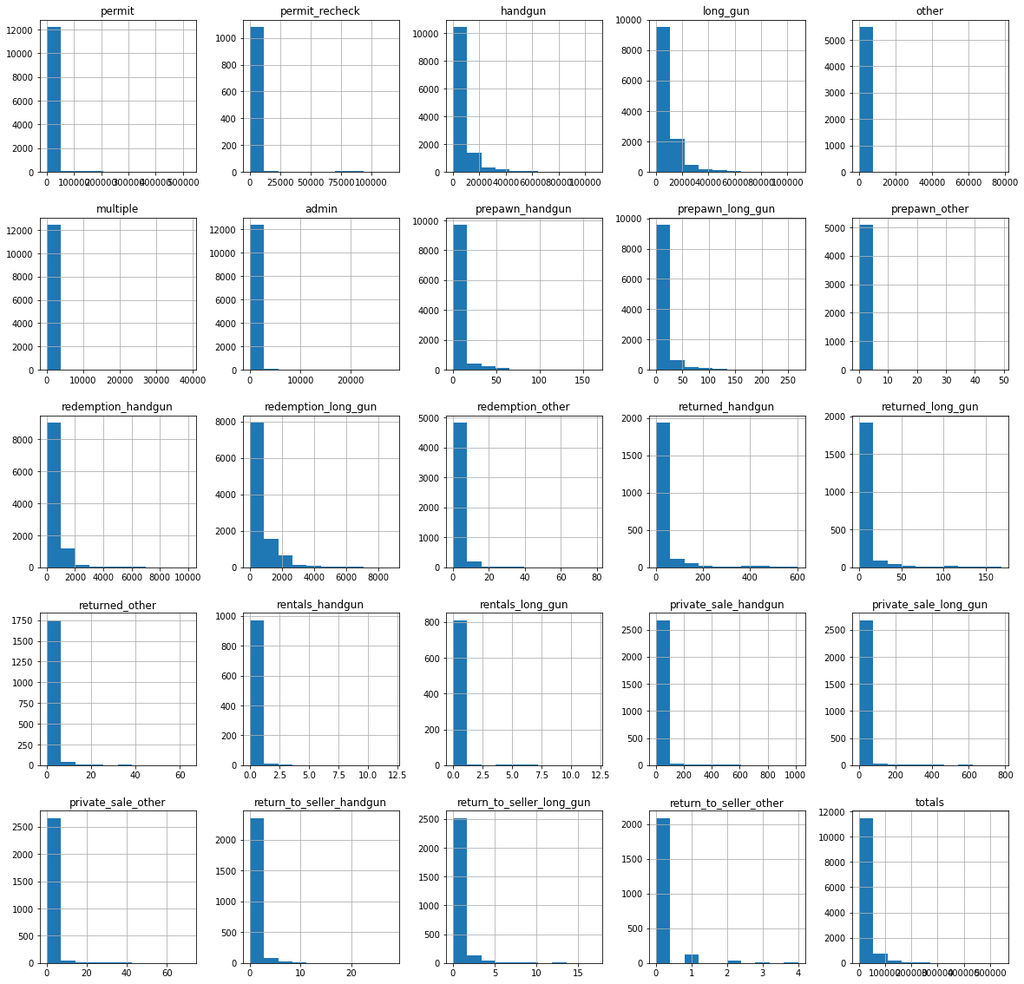

```python
# The average number of checks between years (1998-2017) in Gun DataFrame.
# Use matplotlib.pyplot.hist() to plot a historgram.
# A histogram tells you how many observations or data points fall in various ranges of values.
df_gun.hist(figsize=(20,20));
```

```python
print('-'*120)
```

```python
# Cleaning Data
```

```python
# Create copies of the two DataFrames for Cleaning purposes:
```

```python
df_census_cleaning = df_census.copy()
```

```python
df_gun_cleaning = df_gun.copy()
```

```python
# Define
```

```python
# Remove duplicates
# Use pandas.DataFrame.duplicated() to return boolean Searies denoting duplicate rows
```

```python
df_census_cleaning.duplicated()
```

```
0     False
1     False
2     False
3     False
4     False
      ...
80    False
81    False
82    False
83    False
84    False
Length: 85, dtype: bool
```

```python
df_gun_cleaning.duplicated()
```

```
0        False
1        False
2        False
3        False
4        False
         ...
12480    False
12481    False
12482    False
12483    False
12484    False
Length: 12485, dtype: bool
```

```python
# Sum the numbers of duplicates in the both DataFrames
sum(df_census_cleaning.duplicated()), sum(df_gun_cleaning.duplicated())
```

```
(3, 0)
```

```python
# Code
```

```python
# Use pandas.DataFrame.drop_duplicates() function to remove duplicated rows in the two dataframes
```

```python
df_census_cleaning.drop_duplicates(inplace=True)
```

```python
df_gun_cleaning.drop_duplicates(inplace=True)
```

```python
# Test
```

```python
# Check any number of duplicates in the both DataFrames
sum(df_census_cleaning.duplicated()), sum(df_gun_cleaning.duplicated())
```

```
(0, 0)
```

```python
# Define
```

```python
# Replace missing values (Null or NA values) with 0s.
# Use pandas.DataFrame.isnull() method to detect the missing values (Null values)
```

```python
df_census_cleaning.isnull().any()
```

```
Fact              True
Fact Note         True
Alabama           True
Alaska            True
Arizona           True
Arkansas          True
California        True
Colorado          True
Connecticut       True
Delaware          True
Florida           True
Georgia           True
Hawaii            True
Idaho             True
Illinois          True
Indiana           True
Iowa              True
Kansas            True
Kentucky          True
Louisiana         True
Maine             True
Maryland          True
Massachusetts     True
Michigan          True
Minnesota         True
Mississippi       True
Missouri          True
Montana           True
Nebraska          True
Nevada            True
New Hampshire     True
New Jersey        True
New Mexico        True
New York          True
North Carolina    True
North Dakota      True
Ohio              True
Oklahoma          True
Oregon            True
Pennsylvania      True
Rhode Island      True
South Carolina    True
South Dakota      True
Tennessee         True
Texas             True
Utah              True
Vermont           True
Virginia          True
Washington        True
West Virginia     True
Wisconsin         True
Wyoming           True
dtype: bool
```